# MATH1062 Lab2 Worksheet

Introduction to R

© University of Sydney MATH1062

16 August 2024

# Aim of Lab2

**Learning Outcome**  
LO3. identify appropriate methods to describe, summarise and visualise a given data set

LO5. apply statistical software such as R to analyse example sets of data

At the end of this Lab, you should be able to:

- Choose what graphical summaries are appropriate for given variables, and interpret the output.
- Produce graphical summaries with R (histogram, boxplot, barplot), and reclassify variables.

**R commands** `class`, `hist`, `barplot`, `boxplot`, `is.na`, `na.omit`, `sum`, `factor`, …

# Summary

| Type of Variable | Referred to in R |
| --- | --- |
| Qualitative / Categorical | `factor` |
| Quantitative / Numerical | `num` |

| Type of Data | Type of Graphical Summary | In R |
| --- | --- | --- |
| 1 Qualitative Variable | Barplot | `barplot()` |
| 2 Qualitative Variables | Double (clustered) Barplot | `barplot()` |
| 1 Quantitative Variable | Histogram or Boxplot | `hist()`, `boxplot()` |
| 2 Quantitative Variables | Scatterplot | `plot()` |
| 1 Quantitative & 1 Qualitative Variable | Double (comparative) boxplot | `boxplot()` |

# Australian Road Fatalities

Consider the Australian road fatalities from 1989 (a bigger version of the data used in lectures). The data is sourced from [BITRE](https://bitre.gov.au/statistics/safety/fatal_road_crash_database.aspx).

**How to proceed?**

- Check whether you can knit the document without any error. If not, you may need to make sure your `Lab2Worksheet.Rmd` and data file are in the correct folders.
- Read through each question.
- Try to understand the given code.
- Write short concise answers in this file.
- Have a go at the explore questions.

# 1 Import the data.

Note: Recall that you need to store your `Lab2Worksheet.Rmd` in your `MATH1062` folder, then download the data from Canvas, store the data in `MATH1062/data` and then run the code. Alternatively, you can store the data in the same folder as `Lab2Worksheet.Rmd`, and remove the `data/` part of the code. You will need to use this method in future projects, when you import your own data.

```r
# Read data from csv into R
road = read.csv("AllFatalities.csv",header=T)
```

- Produce a snapshot of the data.

```r
str(road)
```

```
## 'data.frame':    46624 obs. of  18 variables:
##  $ CrashID                      : num  4.2e+12 2.2e+12 1.2e+12 5.2e+12 6.2e+12 ...
##  $ State                        : chr  "SA" "VIC" "NSW" "WA" ...
##  $ Date                         : chr  "01-Jan-16" "01-Jan-16" "02-Jan-16" "02-Jan-16" ...
##  $ Day                          : int  1 1 2 2 2 2 3 3 4 4 ...
##  $ Month                        : chr  "January" "January" "January" "January" ...
##  $ Year                         : int  2016 2016 2016 2016 2016 2016 2016 2016 2016 2016 ...
##  $ Dayweek                      : chr  "Friday" "Friday" "Saturday" "Saturday" ...
##  $ Time                         : chr  "1:00" "20:30" "0:30" "17:20" ...
##  $ Hour                         : int  1 20 0 17 19 19 11 14 2 15 ...
##  $ Minute                       : int  0 30 30 20 58 58 55 0 0 47 ...
##  $ Crash_Type                   : chr  "Single" "Single" "Single" "Multiple" ...
##  $ Bus_Involvement              : chr  "No " "No " "No " "No " ...
##  $ Hvy_Rigid_Truck_Involvement  : chr  "No " "No " "No " "No " ...
##  $ Articulated_Truck_Involvement: chr  "No " "No " "No " "Yes" ...
##  $ Speed_Limit                  : chr  "110" "80" "100" "110" ...
##  $ Road_User                    : chr  "Driver" "Motor cycle rider" "Passenger" "Driver" ...
##  $ Gender                       : chr  "Male" "Male" "Male" "Male" ...
##  $ Age                          : chr  "40" "25" "18" "53" ...
```

# 2 Research Questions

## 2.1 Were there more fatalities on a certain day of the week?

- Here we consider **1 qualitative variable**: the road fatalities across the *days of the week*.
- First isolate the variable `Dayweek`. Check how R classifies it. Produce a barplot. You may see that the days are in the wrong order. This is because that R automatically sorts factors alphabetically unless we impose an ordering.

```r
dayweek = road$Dayweek # isolate the variable Dayweek
class(dayweek) # check how R classify it
```

```
## [1] "character"
```

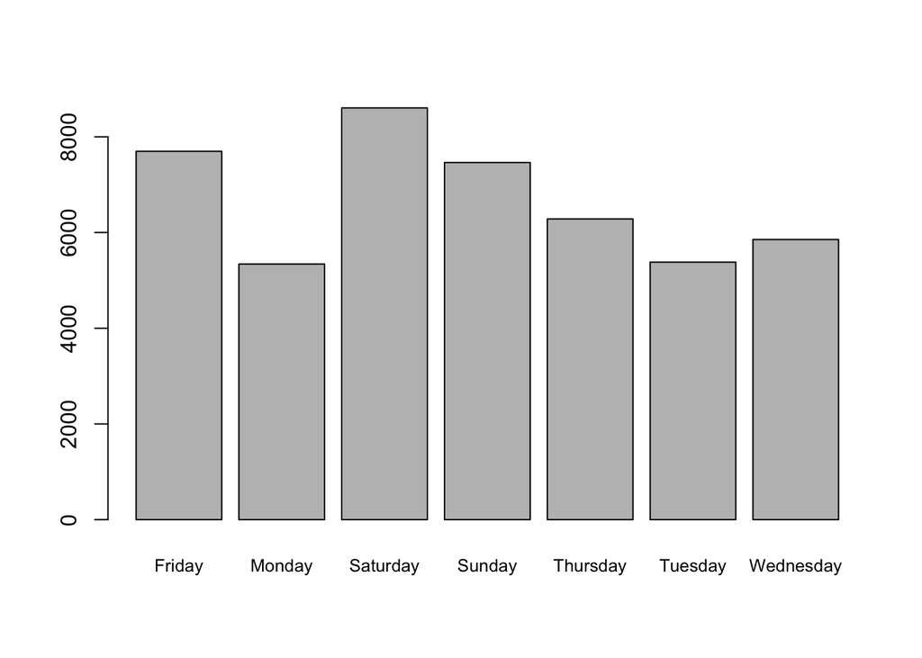

```r
### Write your code below to produce the barplot
barplot(table(dayweek), cex.names = 0.8)
```

- We can re-order the categories for `dayweek` and then re-produce a barplot (see lecture slides). What pattern emerges? Suggest possible reasons for it.

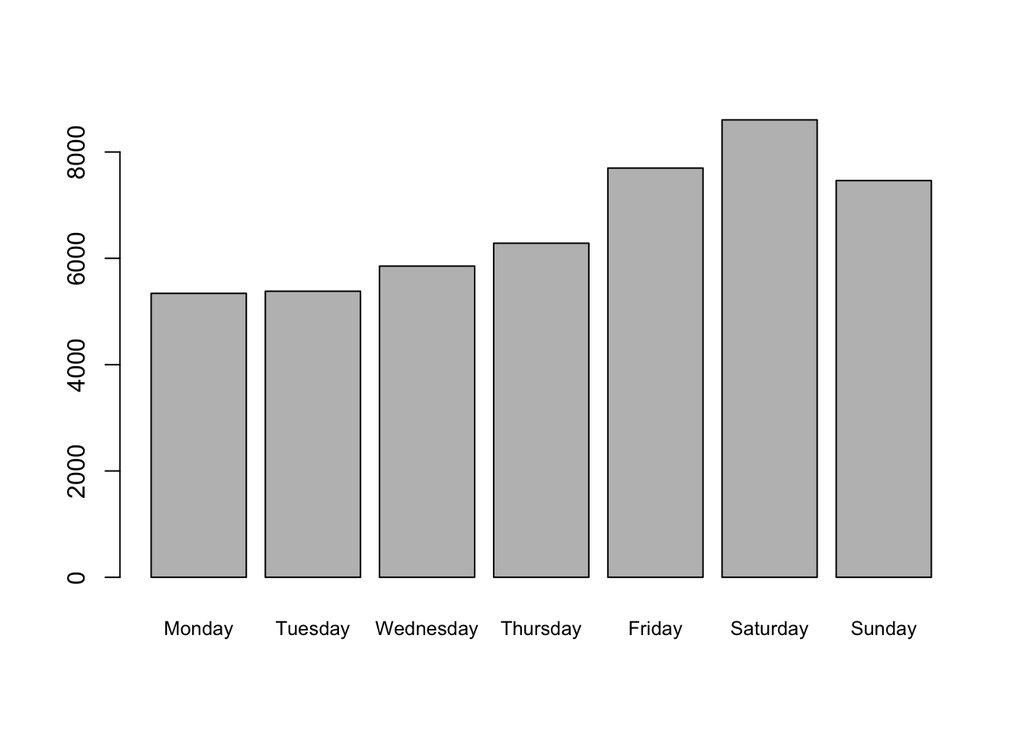

```r
### Write your code here
dayweek = factor(dayweek, levels = c("Monday", "Tuesday", "Wednesday", "Thursday", "Friday", "Saturday", "Sunday"))

barplot(table(dayweek), cex.names = 0.8)
```

```r
# The highest number of fatalities occur on Friday and Saturday.
```

In the barplot, you can use the option `las=2` to display the category labels vertically, try it out below.

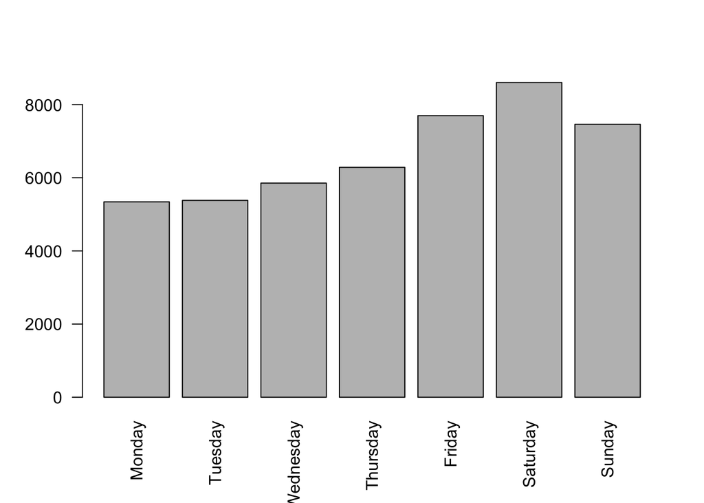

```r
### Write your code here
barplot(table(dayweek), las = 2)
```

- Summarise what you have discovered.

## 2.2 Were there more fatalities in certain age groups?

- Here we consider **1 quantitative variable**: *age*.
- First isolate the variable `Age`. How does R classify it?

```r
age = road$Age
class(age)
```

```
## [1] "character"
```

- Change the classification to a quantitative variable (use `as.numeric()`).

```r
### Write your code here
age = as.numeric(age)
class(age)
```

```
## [1] "numeric"
```

- Produce graphical summaries (try boxplot and histogram). What patterns are revealed?

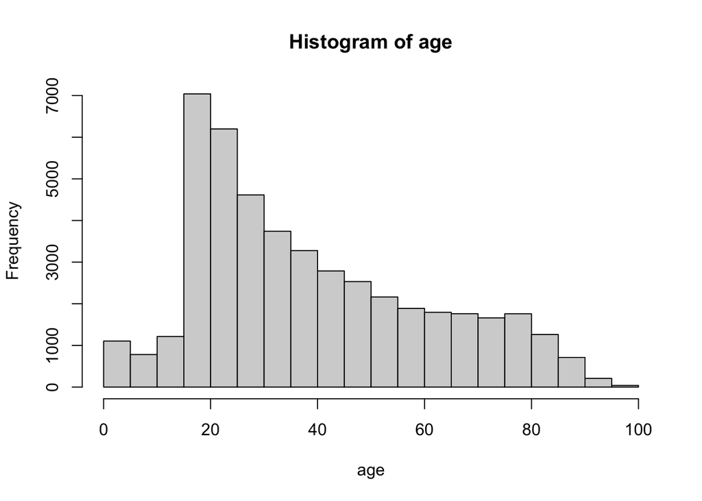

```r
### Write your code here
hist(age)
```

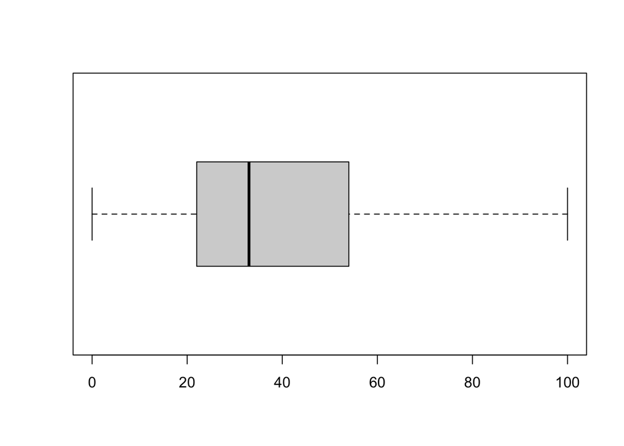

```r
boxplot(age,horizontal = TRUE)
```

```r
# Right skewed
```

- Summarise what you have discovered.

## 2.3 Does gender affect the number of fatalities across age groups?

- Here we consider **1 quantitative variable divided by 1 qualitative variable**.
- Control for gender (using comparative boxplot) - i.e., consider fatalities by age divided by gender.

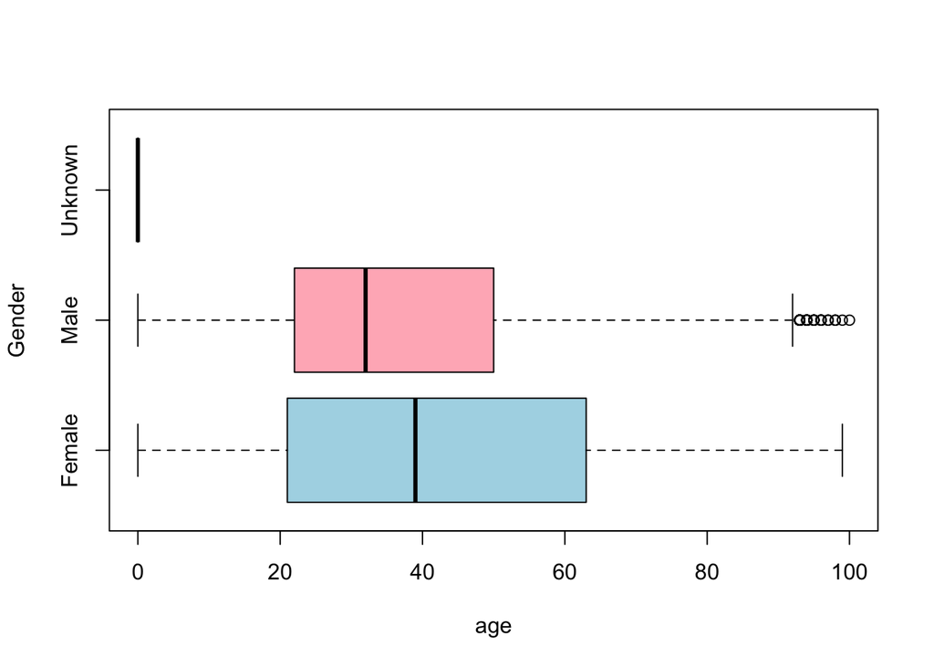

```r
### Write your code here

boxplot(age~Gender, data = road,col = c("lightblue", "lightpink"), horizontal = TRUE)
```

```r
# (quntitative~qualitative)
```

- Summarise what you have discovered.

## 2.4 Was there any pattern in how buses were involved in fatalities, on different days of the week?

- Here we consider **2 qualitative variables**: the road fatalities across the *days of the week*, cross-classified by *bus involvement*.
- Is there any pattern?

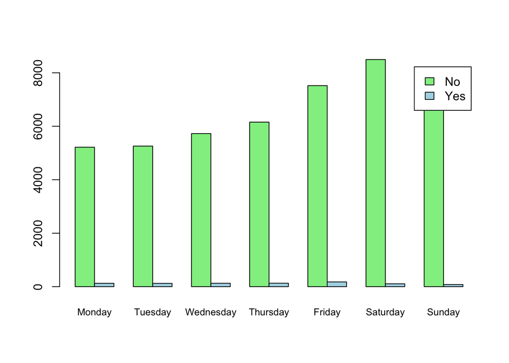

```r
### Write your code here
bus_inv = road$Bus_Involvement
data1 = table(bus_inv,dayweek)

barplot(data1,beside = TRUE,legend = rownames(data1),col = c("lightgreen", "lightblue"),cex.names = 0.8)
```

- Summarise what you have discovered.

Most Fatal Accidents Do Not Involve Buses:

The number of fatal road accidents without bus involvement peaks on Friday and Saturday, with a slight drop on Sunday.

## 2.5 Data selection

How many deaths were happened at age under 45 and on Saturday? Here you need to consider how to deal with data points with value `NA`

```r
### Write your code here
nrow(road[!is.na(road$Age) & road$Age < 45 & road$Dayweek == "Saturday", ])
```

```
## [1] 6056
```

How many deaths were happened at age under 45 and NOT on Saturday?

```r
##### Write your code here
nrow(road[!is.na(road$Age) & road$Age < 45 & road$Dayweek != "Saturday", ])
```

```
## [1] 23363
```

## 2.6 Were there more fatalities on a certain months of the year?

- Here we consider **1 qualitative variable**: the road fatalities across the *months of the year*.

Hint: `month.name` contains the months of year sorted in the correct order!

```r
month.name
```

```
##  [1] "January"   "February"  "March"     "April"     "May"       "June"
##  [7] "July"      "August"    "September" "October"   "November"  "December"
```

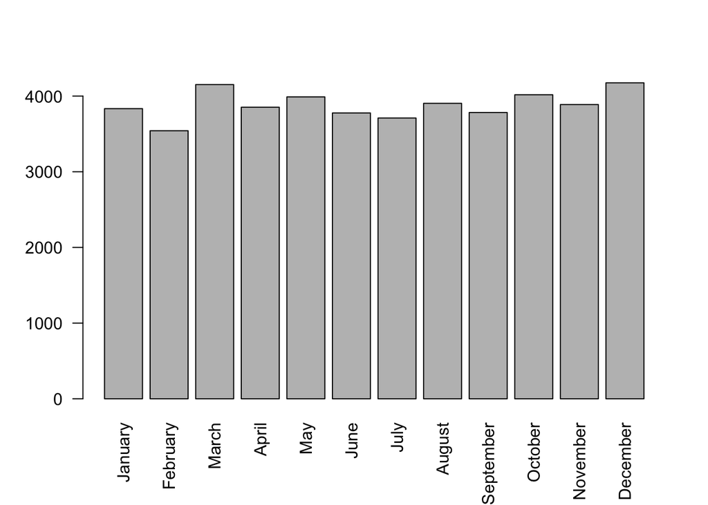

```r
##### Write your code here
month = factor(road$Month, levels = c(month.name))
barplot(table(month), las=2)
```

- Summarise what you have discovered.

## 2.7 Was there any pattern between Age and Crash Type?

- Here we consider **1 quantitative variable divided by 1 qualitative variable**. ie consider fatalities by age divided by crash type.

What are the different Crash Types?

```r
table(road$Crash_Type)
```

```
##
##   Multiple Pedestrian     Single
##      19963       7424      19237
```

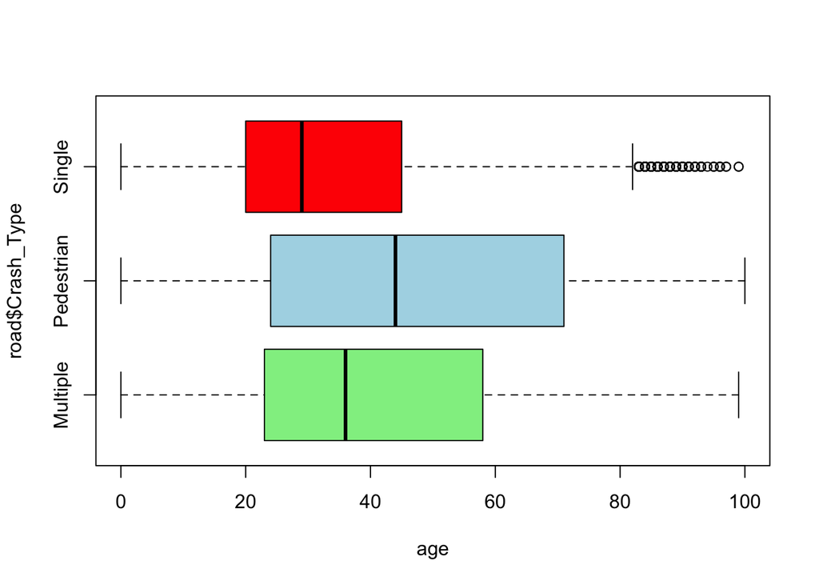

```r
### Write your code here
boxplot(age~road$Crash_Type, horizontal = TRUE, col = c("lightgreen","lightblue","red") )
```

- Summarise what you have discovered.

## 2.8 Was there any pattern in how heavy rigid trucks were involved in fatalities, on different days of the week?

- Here we consider **2 qualitative variables**: the road fatalities across the *days of the week*, cross-classified by *heavy rigid truck involvement*. Note you may need to deal with missing values!

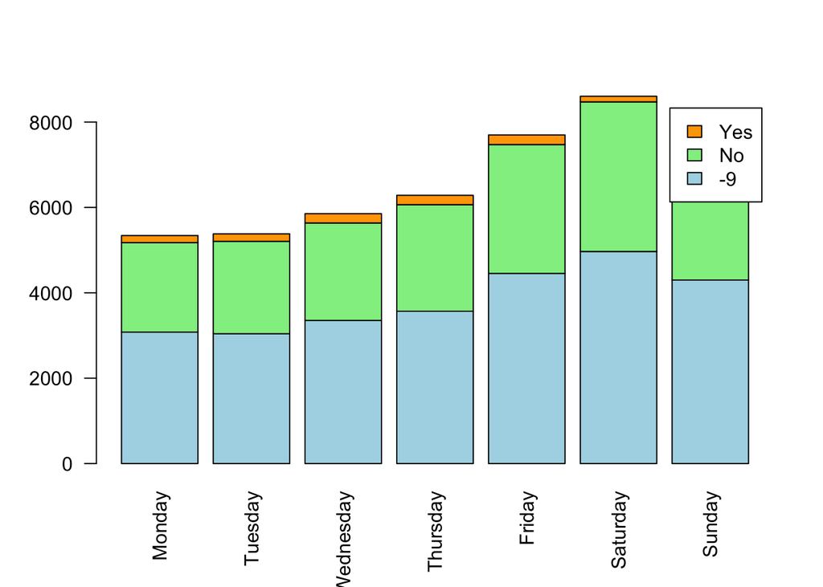

```r
### Write your code here

data2 = table(road$Hvy_Rigid_Truck_Involvement,dayweek)
barplot(data2, las = 2,legend = rownames(data2),col = c( "lightblue", "lightgreen", "orange"))
```

- Summarise what you have discovered.

# 3 Challenge

Visualise some of the other variables in the data, and see if you can find any interesting trends.